# The ‘Time Machine’ Credit Scorecard

Longitudinal Decay, Early-Warning Surveillance, and Intervention Strategies in Unsecured Lending

Credit Risk Analytics & Modelling

2026-10-30

# 1 Executive Summary

Credit risk scorecards deployed in commercial banking inevitably face environmental drift. Unlike randomized cross-validation in standard machine learning, financial risk models must navigate macroeconomic regime shifts, changing underwriting policies, and population aging.

This study constructs the **“Time Machine”** credit risk experiment: 1. **Model Build (2012–2014):** A weight-of-evidence (WOE) logistic scorecard is developed on completed 36-month Lending Club loans. 2. **Validation & Cut-off (2015):** The model is validated out-of-time (OOT) and an approval cut-off is set at the 70th percentile of scores. 3. **Frozen Longitudinal Run (2016–2018):** The scorecard is frozen and evaluated across future cohorts without retraining to quantify decay in discrimination ($Gini$), calibration gap ($\text{Calib Gap}$), and profitability. 4. **Surveillance & Early Warning:** Population Stability Index (PSI) and Characteristic Stability Index (CSI) are monitored against pre-set supervisory thresholds. 5. **Remediation Economics:** Three management policies are evaluated: **Strategy A** (Do Nothing), **Strategy B** (Reset Cut-off), and **Strategy C** (Rolling Rebuild).

# 2 Stage 1: Data Ingestion & Pre-Origination Hygiene

To prevent data leakage, we retain strictly pre-origination attributes known at application time. Post-origination servicing history and Lending Club’s proprietary credit `grade` / `sub_grade` / `int_rate` are purged.

```r
# Load cleaned dataset from cache or process raw file
if (file.exists("data/df_cleaned.rds")) {
  df <- readRDS("data/df_cleaned.rds")
} else {
  source("01_load_clean.R")
}

feat <- setdiff(names(df), c("bad", "issue_year"))

cat(sprintf("Cleaned Dataset: %s observations across %d features.\n",
            format(nrow(df), big.mark = ","), length(feat)))
```

```
## Cleaned Dataset: 60,000 observations across 19 features.
```

```r
# Check vintage distribution
table(df$issue_year)
```

```
##
##  2012  2013  2014  2015  2016  2017  2018
##  4965  7166 10765 13425 10565  7053  6061
```

# 3 Stage 2: Exploratory Data Analysis & Seasoning Bias

We inspect cohort volume, default prevalence, and applicant risk tiers.

```r
# Portfolio volume and bad rate by vintage
vintage_tbl <- df %>%
  group_by(issue_year) %>%
  summarise(
    loans = n(),
    bads = sum(bad),
    bad_rate = mean(bad),
    mean_fico = mean(fico, na.rm = TRUE),
    mean_dti = mean(dti, na.rm = TRUE),
    .groups = "drop"
  )

kable(vintage_tbl, digits = 4, caption = "Origination Cohort Overview (2012-2018)")
```

Origination Cohort Overview (2012-2018)

| issue_year | loans | bads | bad_rate | mean_fico | mean_dti |
| --- | --- | --- | --- | --- | --- |
| 2012 | 4965 | 483 | 0.0973 | 695.9857 | 18.0458 |
| 2013 | 7166 | 711 | 0.0992 | 694.7498 | 18.2741 |
| 2014 | 10765 | 1080 | 0.1003 | 695.0369 | 18.8737 |
| 2015 | 13425 | 1379 | 0.1027 | 694.9610 | 19.0846 |
| 2016 | 10565 | 1110 | 0.1051 | 694.9970 | 19.7277 |
| 2017 | 7053 | 619 | 0.0878 | 694.8480 | 19.9502 |
| 2018 | 6061 | 470 | 0.0775 | 694.7045 | 20.3978 |

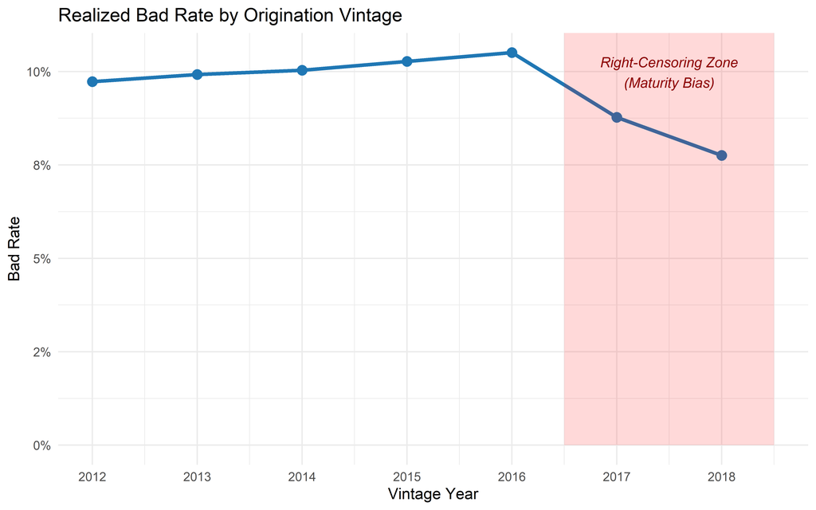

Realized Bad Rate by Origination Vintage with Seasoning Zone

```r
ggplot(vintage_tbl, aes(x = issue_year, y = bad_rate)) +
  geom_line(color = "#1f77b4", linewidth = 1.2) +
  geom_point(color = "#1f77b4", size = 3) +
  annotate("rect", xmin = 2016.5, xmax = 2018.5, ymin = 0, ymax = Inf, alpha = 0.15, fill = "red") +
  annotate("text", x = 2017.5, y = max(vintage_tbl$bad_rate) * 0.95,
           label = "Right-Censoring Zone\n(Maturity Bias)", color = "darkred", size = 3.5, fontface = "italic") +
  scale_y_continuous(labels = percent_format(accuracy = 1)) +
  scale_x_continuous(breaks = min(vintage_tbl$issue_year):max(vintage_tbl$issue_year)) +
  labs(title = "Realized Bad Rate by Origination Vintage", x = "Vintage Year", y = "Bad Rate") +
  theme_minimal()
```

# 4 Stage 3: Scorecard Build on 2012–2014 Cohort

We bin candidate features using tree-based Weight of Evidence (WOE), filter by Information Value ($IV \ge 0.02$), estimate a logistic regression, and scale log-odds into standard scorecard points ($600$ points at $1/19$ odds, $PDO = 50$).

```r
# Load or build scorecard
if (file.exists("data/base_fit.rds")) {
  base_fit <- readRDS("data/base_fit.rds")
  cutoff   <- readRDS("data/cutoff.rds")
} else {
  source("03_build_scorecard.R")
}

summary(base_fit$model)
```

```
##
## Call:
## glm(formula = bad ~ ., family = binomial(), data = woe)
##
## Coefficients:
##                    Estimate Std. Error z value Pr(>|z|)
## (Intercept)        -2.20525    0.02328 -94.723  < 2e-16 ***
## fico_woe            1.02436    0.04957  20.666  < 2e-16 ***
## dti_woe             1.02064    0.06293  16.218  < 2e-16 ***
## revol_util_woe      1.03547    0.08259  12.538  < 2e-16 ***
## inq_last_6mths_woe  1.03928    0.14510   7.162 7.93e-13 ***
## ---
## Signif. codes:  0 '***' 0.001 '**' 0.01 '*' 0.05 '.' 0.1 ' ' 1
##
## (Dispersion parameter for binomial family taken to be 1)
##
##     Null deviance: 14818  on 22895  degrees of freedom
## Residual deviance: 13928  on 22891  degrees of freedom
## AIC: 13938
##
## Number of Fisher Scoring iterations: 5
```

```r
# Model card
model_card <- tibble(
  Variable = names(base_fit$iv),
  Information_Value = round(as.numeric(base_fit$iv), 4),
  Strength = case_when(
    Information_Value >= 0.30 ~ "Strong",
    Information_Value >= 0.10 ~ "Medium",
    TRUE ~ "Weak"
  )
) %>% arrange(desc(Information_Value))

kable(model_card, caption = "Model Card: Selected Predictors & Information Value")
```

Model Card: Selected Predictors & Information Value

| Variable | Information_Value | Strength |
| --- | --- | --- |
| fico | 0.2070 | Medium |
| dti | 0.1227 | Medium |
| revol_util | 0.0741 | Weak |
| inq_last_6mths | 0.0232 | Weak |

# 5 Stage 4: Longitudinal Fast-Forward Test (2015–2018)

We score all subsequent cohorts with the frozen scorecard and track discrimination, calibration gap, and portfolio profit under stylized bank economics ($MARGIN = 10\%$, $LGD = 60\%$).

```r
if (file.exists("data/perf.rds")) {
  perf <- readRDS("data/perf.rds")
} else {
  source("04_fast_forward_test.R")
}

kable(perf, digits = 4, caption = "Longitudinal Performance of Frozen Scorecard (2015-2018)")
```

Longitudinal Performance of Frozen Scorecard (2015-2018)

| issue_year | loans | bad_rate | mean_pd | calib_gap | gini | approval_rate | bad_rate_approved | profit_per_applicant |
| --- | --- | --- | --- | --- | --- | --- | --- | --- |
| 2015 | 13425 | 0.1027 | 0.1015 | -0.0120 | 0.3294 | 0.7007 | 0.0725 | 531.7706 |
| 2016 | 10565 | 0.1051 | 0.1042 | -0.0086 | 0.3172 | 0.6827 | 0.0725 | 531.1415 |
| 2017 | 7053 | 0.0878 | 0.1061 | 0.2092 | 0.3436 | 0.6749 | 0.0563 | 680.4920 |
| 2018 | 6061 | 0.0775 | 0.1085 | 0.3997 | 0.3331 | 0.6580 | 0.0481 | 739.7080 |

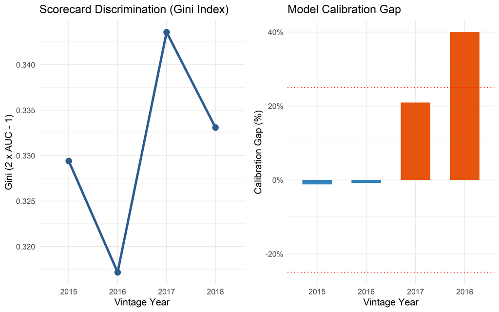

Discrimination (Gini) and Calibration Gap Trends

```r
p_g <- ggplot(perf, aes(x = factor(issue_year), y = gini, group = 1)) +
  geom_line(color = "#2b5c8f", linewidth = 1.3) +
  geom_point(color = "#2b5c8f", size = 3) +
  labs(title = "Scorecard Discrimination (Gini Index)", x = "Vintage Year", y = "Gini (2 x AUC - 1)") +
  theme_minimal()

p_c <- ggplot(perf, aes(x = factor(issue_year), y = calib_gap, fill = calib_gap > 0)) +
  geom_col(width = 0.6) +
  geom_hline(yintercept = c(-0.25, 0.25), linetype = "dotted", color = "red") +
  scale_y_continuous(labels = percent_format(accuracy = 1)) +
  scale_fill_manual(values = c("TRUE" = "#e6550d", "FALSE" = "#3182bd"), guide = "none") +
  labs(title = "Model Calibration Gap", x = "Vintage Year", y = "Calibration Gap (%)") +
  theme_minimal()

gridExtra::grid.arrange(p_g, p_c, ncol = 2)
```

# 6 Stage 5: Early-Warning Surveillance (PSI & CSI)

We evaluate score divergence via Population Stability Index (PSI) and input variable drift via Characteristic Stability Index (CSI).

```r
if (file.exists("data/alerts.rds")) {
  alerts  <- readRDS("data/alerts.rds")
  csi_tbl <- readRDS("data/csi_tbl.rds")
} else {
  source("05_early_warning_signals.R")
}

kable(alerts %>% select(issue_year, gini, gini_drop, calib_gap, psi, alert, decayed),
      digits = 4, caption = "Surveillance Alert Log (PSI > 0.25 | |Calib Gap| > 0.25)")
```

Surveillance Alert Log (PSI > 0.25 | |Calib Gap| > 0.25)

| issue_year | gini | gini_drop | calib_gap | psi | alert | decayed |
| --- | --- | --- | --- | --- | --- | --- |
| 2015 | 0.3294 | 0.0000 | -0.0120 | 0.0021 | FALSE | FALSE |
| 2016 | 0.3172 | 0.0122 | -0.0086 | 0.0069 | FALSE | FALSE |
| 2017 | 0.3436 | -0.0142 | 0.2092 | 0.0114 | FALSE | FALSE |
| 2018 | 0.3331 | -0.0037 | 0.3997 | 0.0230 | TRUE | FALSE |

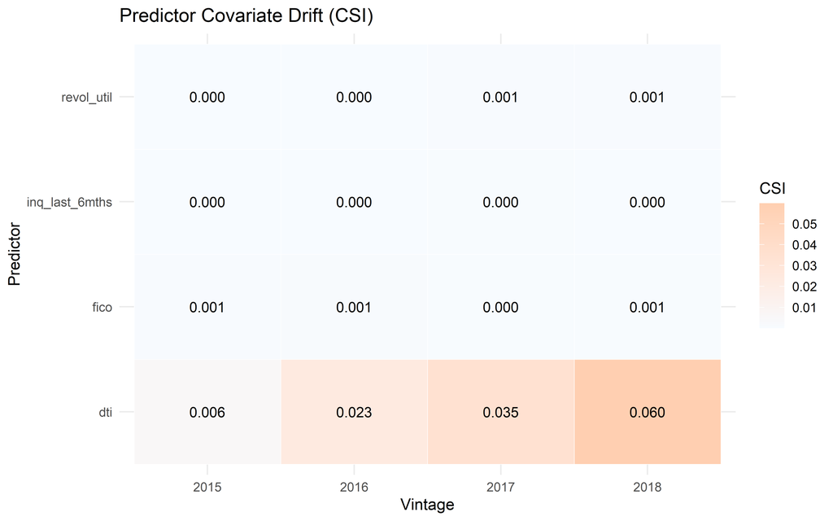

Characteristic Stability Index (CSI) Heatmap Across Model Features

```r
ggplot(csi_tbl, aes(x = factor(year), y = clean_var, fill = csi)) +
  geom_tile(color = "white") +
  geom_text(aes(label = sprintf("%.3f", csi)), size = 3.5, color = ifelse(csi_tbl$csi > 0.15, "white", "black")) +
  scale_fill_gradient2(low = "#f7fbff", mid = "#fd8d3c", high = "#b30000", midpoint = 0.15) +
  labs(title = "Predictor Covariate Drift (CSI)", x = "Vintage", y = "Predictor", fill = "CSI") +
  theme_minimal()
```

# 7 Stage 6: Remediation Strategies & Decision Economics

We benchmark three intervention strategies across test vintages 2016–2018: - **Strategy A (Do Nothing):** Retain frozen 2012–2014 scorecard and 2015 cut-off. - **Strategy B (Reset Cut-off):** Dynamically reset cut-off annually to maintain target 70% approval. - **Strategy C (Rebuild):** Retrain scorecard on trailing 3-year rolling window.

```r
if (file.exists("data/strategies.rds")) {
  strategies   <- readRDS("data/strategies.rds")
  sens_results <- readRDS("data/sens_results.rds")
} else {
  source("06_remediation_strategies.R")
}

kable(strategies %>% select(issue_year, strategy, approval_rate, bad_rate_approved, gini, profit_per_applicant),
      digits = 4, caption = "Remediation Policy Comparison (2016-2018)")
```

Remediation Policy Comparison (2016-2018)

| issue_year | strategy | approval_rate | bad_rate_approved | gini | profit_per_applicant |
| --- | --- | --- | --- | --- | --- |
| 2016 | A: Do Nothing | 0.6827 | 0.0725 | 0.3172 | 531.1415 |
| 2016 | B: Reset Cut-off | 0.6827 | 0.0725 | 0.3172 | 531.1415 |
| 2016 | C: Rebuild | 0.6772 | 0.0739 | 0.3169 | 521.2731 |
| 2017 | A: Do Nothing | 0.6749 | 0.0563 | 0.3436 | 680.4920 |
| 2017 | B: Reset Cut-off | 0.7092 | 0.0596 | 0.3436 | 691.3923 |
| 2017 | C: Rebuild | 0.7205 | 0.0614 | 0.3430 | 691.2817 |
| 2018 | A: Do Nothing | 0.6580 | 0.0481 | 0.3331 | 739.7080 |
| 2018 | B: Reset Cut-off | 0.6934 | 0.0533 | 0.3331 | 736.6474 |
| 2018 | C: Rebuild | 0.6758 | 0.0552 | 0.3190 | 707.7297 |

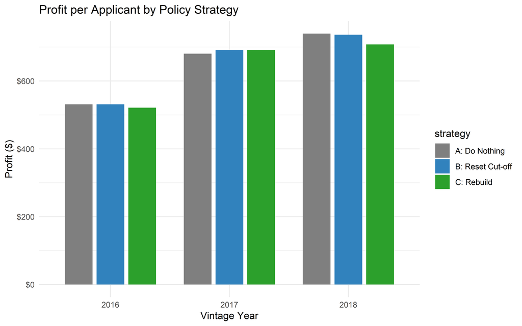

Net Portfolio Profit per Applicant Across Remediation Policies

```r
ggplot(strategies, aes(x = factor(issue_year), y = profit_per_applicant, fill = strategy)) +
  geom_col(position = position_dodge(width = 0.8), width = 0.7) +
  scale_fill_manual(values = c("A: Do Nothing" = "#7f7f7f", "B: Reset Cut-off" = "#3182bd", "C: Rebuild" = "#2ca02c")) +
  scale_y_continuous(labels = dollar_format()) +
  labs(title = "Profit per Applicant by Policy Strategy", x = "Vintage Year", y = "Profit ($)") +
  theme_minimal()
```

### 7.0.1 Parameter Sensitivity Analysis

```r
kable(sens_results %>% select(scenario, margin, lgd, strategy, avg_profit_per_app),
      digits = 2, caption = "Economic Sensitivity Grid (Margin vs LGD)")
```

Economic Sensitivity Grid (Margin vs LGD)

| scenario | margin | lgd | strategy | avg_profit_per_app |
| --- | --- | --- | --- | --- |
| Base Case | 0.10 | 0.6 | A: Do Nothing | 650.45 |
| Base Case | 0.10 | 0.6 | B: Reset Cut-off | 653.06 |
| Base Case | 0.10 | 0.6 | C: Rebuild | 640.09 |
| Stressed Loss | 0.08 | 0.7 | A: Do Nothing | 374.33 |
| Stressed Loss | 0.08 | 0.7 | B: Reset Cut-off | 364.57 |
| Stressed Loss | 0.08 | 0.7 | C: Rebuild | 352.80 |
| High Margin | 0.12 | 0.5 | A: Do Nothing | 926.56 |
| High Margin | 0.12 | 0.5 | B: Reset Cut-off | 941.55 |
| High Margin | 0.12 | 0.5 | C: Rebuild | 927.39 |

# 8 Governance & Conclusions